# L04 Paneldata

Understand and Plot Data over Time

Marco Kühne

12 Mai 2022

# Learning Goals

- Conceptual Skills:
  - Understand panel data. Panel attrition.
  - Distinguish between and within variation.
  - Compare the paired and unpaired t-Test to panel data.
- Data Skills:
  - How `set.seed()` defeats randomness.
  - Find and use *functions* from other people.
  - Tidyverse e.g. `group_by()`, `sample_n()`, `summarize()`, `count()`, `arrange()`.
  - Data Visualization: Panel plots (time series per group).

# Paneldata

Panel data are observations for the same subjects over time. Subjects can be people, households, firms or countries. Panel data are a subset of longitudinal data. Key components are the panel identifier: person (id) and time (year). Every row is a person-year combination (so called *long format*).

Compare these types of data:

- *Cross-section*: One time measurement.
- *Repeated cross-section*: Different people.
- *Panel*: Repeated observations of the same individuals.

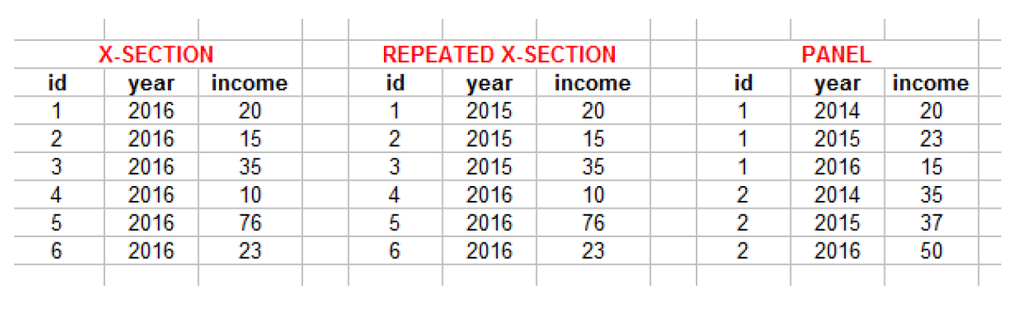

Table 1: Types of Data.

Panel data allows for special statistical analyses, e.g. fixed effects regression. With panel data we know the time-ordering of events. Panel data allow to identify causal effects under weaker assumptions (compared to cross-sectional data). Different types of data can answer different types of questions:

- Levels: How many people are poor in 2016 in Germany?
- Trends: Has poverty increased or decreased?
- Change: How many people went in and out of poverty?

The unemployment rate in Germany is about 5 % over the last few years (Source: [Annual average unemployment rate in Germany from 2005 to 2022](https://www.statista.com/statistics/227005/unemployment-rate-in-germany/)).

Imagine a college graduate enters the job market. It takes about 3 month to search for jobs, send applications and do the job interviews. Finally she finds a perfect match. After some years the college graduate falls in love with someone who lives in another city, so the student moves to this city, again looking for a job at a new employer.

Imagine another college graduate. He sends 5 applications for various jobs per week. He has several mini jobs to keep afloat. The student realizes that he did not acquire the skills that are expected on the job market. After 2 years, he finally finds a suitable position.

Do you think that is a cause for concern?

**Life after collage.**

[figure not shown]

Panel data allows to analyze the level of unemployment in Germany as well as the changes and trajectories of individuals. We can separate a frictional unemployment component and a permanent unemployment share. Frictional unemployment is a form of unemployment reflecting the gap between someone voluntarily leaving a job and finding another. As such, it is sometimes called search unemployment. Do we accept search unemployment? Is it different from long-term unemployment? What do you think.

Some famous household panel data studies are:

- United States: Panel Study of Income Dynamics (PSID) since 1968
- Germany: Socio-Economic Panel (SOEP) since 1984
- United Kingdom: British Household Panel Survey (BHPS) since 1991
- Australia: Household, Income and Labour Dynamics in Australia Survey (HILDA) since 2001

These scientific datasets can often be analyzed for research and student theses free of charge.

# Data Preparation

Load SOEP practice data from web into temporal memory and into R.

```r
library(haven)
soep <- read_dta("https://github.com/MarcoKuehne/seminars_in_applied_economics/blob/main/Data/soep_lebensz_en.dta?raw=true")
```

# Group by person

`group_by()` is a powerful command, especially when working with panel data. Use `count()` after `group_by()` to get the number of observations of each person (`id`) in the data:

```r
library(tidyverse)
head(soep %>% group_by(id) %>% count())
```

**See result.**

```
## # A tibble: 6 x 2
## # Groups:   id [6]
##      id     n
##   <dbl> <int>
## 1   312     1
## 2   399     2
## 3   457     3
## 4   748     1
## 5   761     2
## 6  1044     5
```

Adding `arrange()` means sorting the data by a variable (i.e. the n) either ascending or descending (from high to low).

```r
soep %>% group_by(id) %>% count() %>% arrange(desc(n))
```

**See result.**

```
## # A tibble: 3,550 x 2
## # Groups:   id [3,550]
##       id     n
##    <dbl> <int>
##  1  1044     5
##  2  1300     5
##  3  1343     5
##  4  1889     5
##  5  2160     5
##  6  2241     5
##  7  3240     5
##  8  3535     5
##  9  3787     5
## 10  4107     5
## # ... with 3,540 more rows
```

Note that the output further tells you `# A tibble: 3,550 x 2`, i.e. there are 3550 ID-groups (or units or people).

Remember that the observation period is between 2000 and 2004, i.e. min is 1 year, max is 5 years.

```
##
## 2000 2001 2002 2003 2004
## 3198 2690 2485 2299 2250
```

*Attrition* is the process of dropout from a panel study.

How many people are observed in all years? Filter for a specific n and check the tibble size again.

```r
soep %>% group_by(id) %>% count() %>% filter(n == 5)
```

**See result.**

```
## # A tibble: 1,851 x 2
## # Groups:   id [1,851]
##       id     n
##    <dbl> <int>
##  1  1044     5
##  2  1300     5
##  3  1343     5
##  4  1889     5
##  5  2160     5
##  6  2241     5
##  7  3240     5
##  8  3535     5
##  9  3787     5
## 10  4107     5
## # ... with 1,841 more rows
```

# Data Visualization

## Average Health per Year

A picture is worth a thousand words. Show a time trend or a relationship at the beginning of your analysis. People fancy plots. Your plot should be interesting and easy to understand. If you think obesity or crime is a problem for society and it’s increasing over time you made a good point of why we should talk about it or analyze it more thoroughly. Actually, after months and years of empirical research, the results often can be summarized in one single plot.

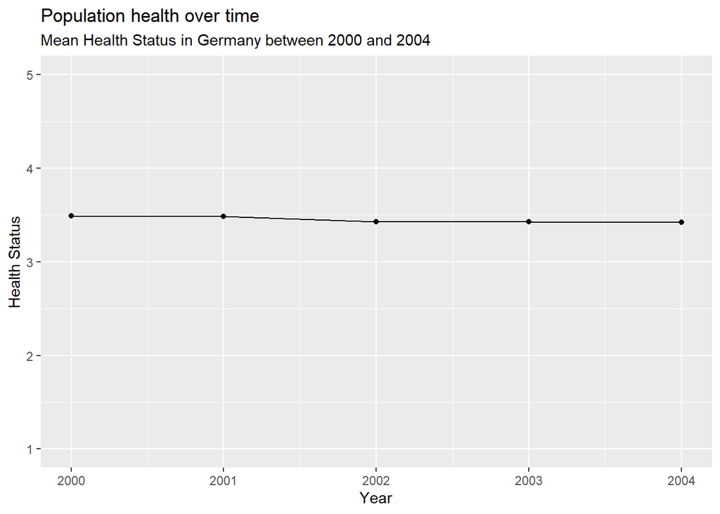

Health status in Germany is stable.

## Individual Health per Year

Next, we dig deeper into personal health stories.

### Random Panel Sample

Let’s use `sample_n()` for random selection of observations. Each time this command is run, a different random set of observations is drawn. Note that these 5 random observations/rows do not stem from the same people.

```r
soep %>% sample_n(5)
```

```
## # A tibble: 5 x 9
##       id  year        sex education no_kids     health_org satisf_org health_std
##    <dbl> <dbl>  <dbl+lbl>     <dbl>   <dbl>      <dbl+lbl>  <dbl+lbl>      <dbl>
## 1 355824  2004 1 [female]        13       0 3 [satisfacto~ 6 [6 Sati~     -0.464
## 2  48569  2002 1 [female]        12       2 1 [bad]        5 [5 Sati~     -2.53
## 3 328516  2002 1 [female]        10       0 3 [satisfacto~ 8 [8 Sati~     -0.464
## 4 378107  2002 0 [male]          11       0 4 [good]       8 [8 Sati~      0.567
## 5 326017  2004 1 [female]        13      NA 4 [good]       8 [8 Sati~      0.567
## # ... with 1 more variable: satisf_std <dbl>
```

If you plant a seed with `set.seed` randomness becomes reproducible.

```r
set.seed(42)
soep %>% sample_n(5)
```

```
## # A tibble: 5 x 9
##       id  year        sex education no_kids     health_org satisf_org health_std
##    <dbl> <dbl>  <dbl+lbl>     <dbl>   <dbl>      <dbl+lbl>  <dbl+lbl>      <dbl>
## 1 564721  2001 1 [female]      11.5       0 4 [good]       8 [8 Sati~      0.567
## 2 643474  2003 0 [male]        NA         2 4 [good]       7 [7 Sati~      0.567
## 3 121058  2003 1 [female]      10.5       0 3 [satisfacto~ 5 [5 Sati~     -0.464
## 4 268036  2004 1 [female]      NA         0 3 [satisfacto~ 9 [9 Sati~     -0.464
## 5 481638  2004 0 [male]        11.5       2 4 [good]       8 [8 Sati~      0.567
## # ... with 1 more variable: satisf_std <dbl>
```

### Personalize Functions

Is there a `sample_n_groups` command in the tidyverse? Unfortunately not. Even in such a case, it’s unlikely that you need to invent something new. One of the first Google hits is: https://cmdlinetips.com/2019/07/how-to-randomly-select-groups-in-r-with-dplyr/ and they suggest:

```r
sample_n_groups = function(grouped_df, size, replace = FALSE, weight=NULL) {
  grp_var <- grouped_df %>%
    groups %>%
    unlist %>%
    as.character
  random_grp <- grouped_df %>%
    summarise() %>%
    sample_n(size, replace, weight) %>%
    mutate(unique_id = 1:NROW(.))
  grouped_df %>%
    right_join(random_grp, by=grp_var) %>%
    group_by_(grp_var)
}
```

If you run this chunk the function `sample_n_groups` appears in the right upper panel in RStudio. Now you can use this particular function in your current session. Don’t worry, you don’t have to understand everything from the code provided by others, but make sure that it behaves the way you expect it to. Since this function is based on `dplyr` commands you can use it within a pipe chain, e.g. pipe it into a ggplot.

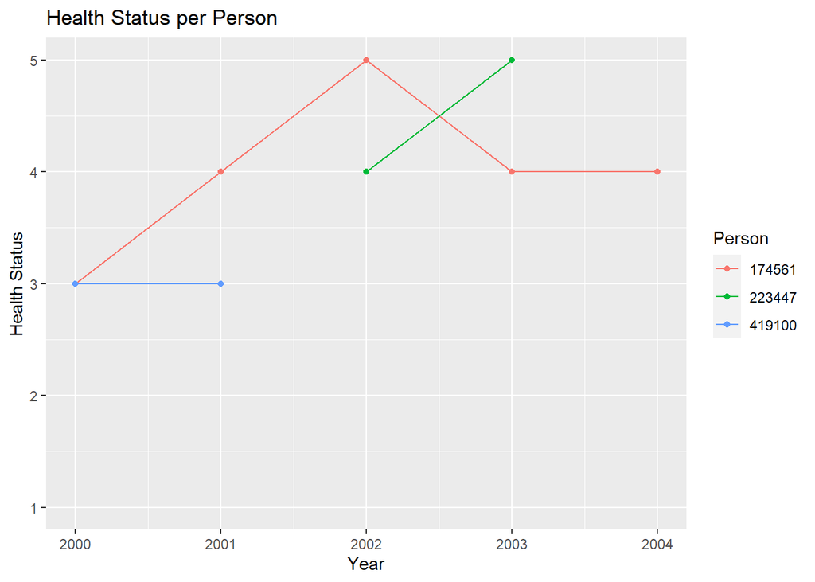

```r
set.seed(42+42)

soep %>%
  group_by(id) %>%
  sample_n_groups(3) %>% # select all given observations across time for 5 people
  ggplot(aes(x = year, y = health_org, group=as_factor(id), color=as_factor(id))) +
  geom_line() + geom_point() +
  labs(title="Health Status per Person",
       x="Year", y="Health Status", color="Person") +
  ylim(1,5)
```

This is test data from the practice data set. It might be helpful to understand what people we selected to compare our code results. Working with real questionnaire data, next show personal information. If you really need a graph like this, drop the legend.

Never show person IDs in a report.

### Minimum Observations per Group

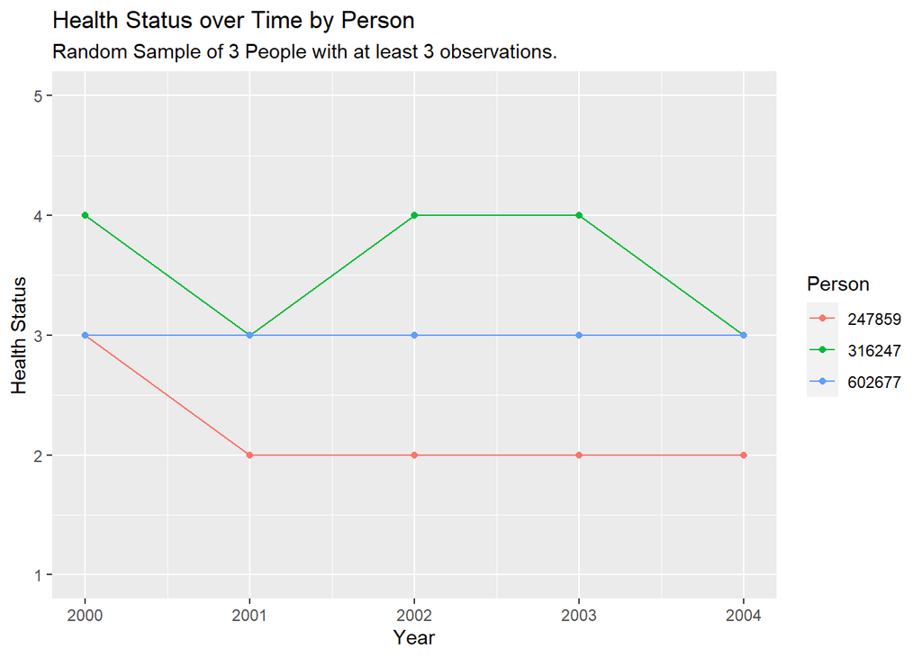

```r
set.seed(42+42)

soep %>%
  group_by(id) %>%
  filter(n()>=3) %>%  # the moment we drop some data
  sample_n_groups(3) %>% # select all given observations across time for 3 people
  ggplot(aes(x = year, y = health_org, col=factor(id))) +
  geom_line() + geom_point() + # add points connected by lines
  labs(title="Health Status over Time by Person",
       subtitle="Random Sample of 3 People with at least 3 observations.",
       x="Year", y="Health Status", colour="Person") + # give some illustrative labels
  ylim(1,5) # limit the scale always to all possible values, to prevent random misperceptions
```

# Within and Between Variation

Here is a similar plot of life satisfaction for selected people.

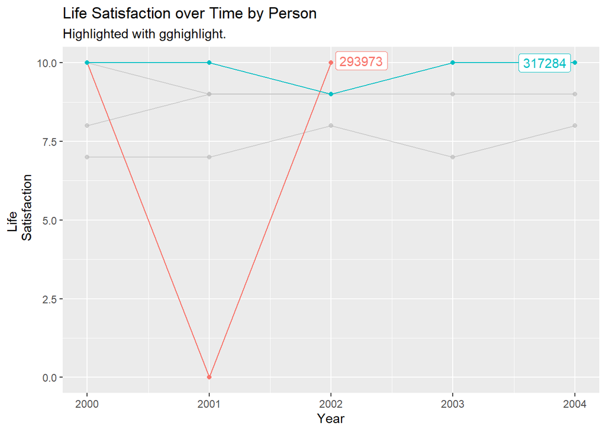

Person 293973 reports a dramatic change in satisfaction from one year to another. Starting from perfect happiness in 2000 (= 10), it drops to complete misery (= 0) and recovers immediately in 2002 (= 10).

**Is person 293973 an outlier? Can you think of reasonable scenarios behind the data?**

*Job’s news*: take away all that a person holds dear, including children, health, and property. Because this is practice data and we cannot dig deeper into life events potentially triggering these changes.

Look at the previous graph from this perspective:

- **Within variation**: *Within* means per individual, group or unit over time.
- **Between variation**: *Between* means comparing individuals, groups or units (both at a point in time or over time).

In 2000 person 293973 and person 317284 both reported a happiness value of 10. In 2000, there is no **difference between** those two people. In 2001 though, 293973 experienced a critical shock and dropped to 0 while 317284 stayed at the very same value of 10. In 2001, the difference between both is 10.

Compare the years 2000 and 2001 for person 293973. The value changes within that person by -10, whereas there is no change for person 317284. You often read about **changes** within people (across time) and about **differences** between them. In the line plot, **within changes** happens along the horizontal x-axis, whereas **between differences** can be measured as the vertical distance on the y-axis.

**Between and within variation** are new properties of a panel data variable.

To fully exploit panel data, we need **enough within variation**.

**Is there enough within variation?**

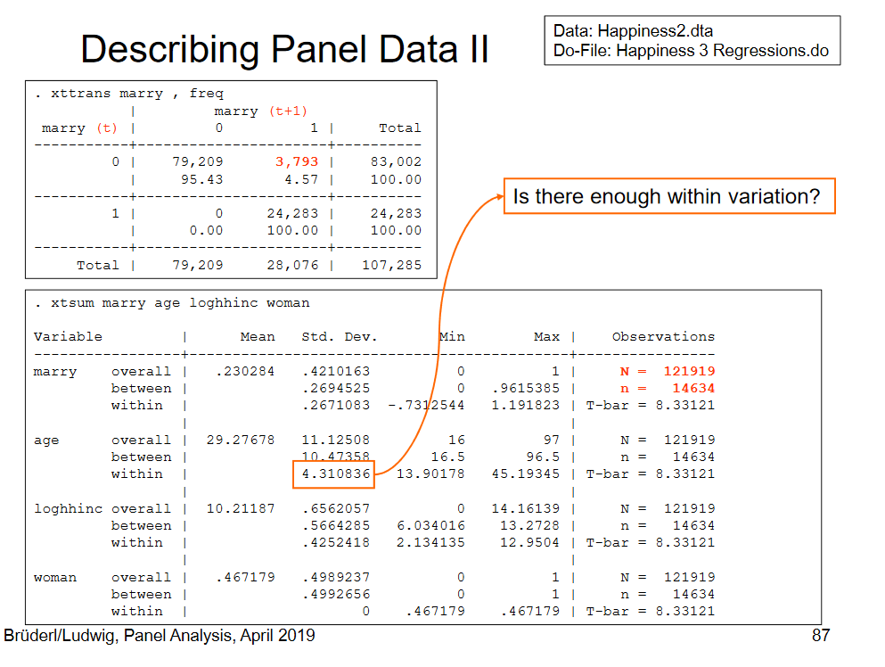

Figure 2: Screenshot from a [lecture script of Brüderl and Ludwig.](https://www.ls3.soziologie.uni-muenchen.de/studium-lehre/archiv/teaching-marterials/panel-analysis_april-2019.pdf) The software is Stata.

## XTSUM (from Stata)

In Stata there is a command **xtsum** which **calculates overall, between and within variation**. This is not implemented in any R package so far. Still, clever people created another personal function on Stack Overflow https://stackoverflow.com/questions/49282083/xtsum-command-for-r:

**Show me the crazy xtsum code.**

```r
# Again, copy the code and run it, and you can use it in your R session.
library(rlang)

XTSUM <- function(data, varname, unit) {
  varname <- enquo(varname)
  loc.unit <- enquo(unit)
ores <- data %>% summarise(ovr.mean=mean(!! varname, na.rm=TRUE), ovr.sd=sd(!! varname, na.rm=TRUE), ovr.min = min(!! varname, na.rm=TRUE), ovr.max=max(!! varname, na.rm=TRUE), ovr.N=sum(as.numeric((!is.na(!! varname)))))
bmeans <- data %>% group_by(!! loc.unit) %>% summarise(meanx=mean(!! varname, na.rm=T), t.count=sum(as.numeric(!is.na(!! varname))))
bres <- bmeans %>% ungroup() %>% summarise(between.sd = sd(meanx, na.rm=TRUE), between.min = min(meanx, na.rm=TRUE), between.max=max(meanx, na.rm=TRUE), Units=sum(as.numeric(!is.na(t.count))), t.bar=mean(t.count, na.rm=TRUE))
wdat <- data %>% group_by(!! loc.unit) %>% mutate(W.x = scale(!! varname, scale=FALSE))
wres <- wdat %>% ungroup() %>% summarise(within.sd=sd(W.x, na.rm=TRUE), within.min=min(W.x, na.rm=TRUE), within.max=max(W.x, na.rm=TRUE))
return(list(ores=ores,bres=bres,wres=wres))
}
```

We can use this functionality to compare our prior results.

```r
library(sjlabelled)
minipanel <- soep %>%
  filter(id %in% c(293973,317284)) %>%
  remove_all_labels()

XTSUM(minipanel, varname=satisf_org, unit=id)
```

```
## $ores
##   ovr.mean  ovr.sd ovr.min ovr.max ovr.N
## 1    8.625 3.50255       0      10     8
##
## $bres
## # A tibble: 1 x 5
##   between.sd between.min between.max Units t.bar
##        <dbl>       <dbl>       <dbl> <dbl> <dbl>
## 1       2.22        6.67         9.8     2     4
##
## $wres
## # A tibble: 1 x 3
##   within.sd within.min within.max
##       <dbl>      <dbl>      <dbl>
## 1      3.10      -6.67       3.33
```

`XTSUM` tells us some more results. The overall mean is 8.62 as expected. The overall smallest value of satisfaction is 0, the highest is 10. We saw this in the graph. We have *N=8* observations or rows. But we only have *n=2* units (see the medium panel). Units (people) are observed on average for `t.bar = 4` periods (one person 3 years, one person 5 years, makes 4 years on average).

Standard deviation `sd` is at the core of **within and between variation** (since it is a measure of dispersion or variation). In the previous graph, we focused on **within changes** and **between differences**.

Think about examples (i.e. variables) that you expect to not have within variation.

Run `XTSUM()` on different variables to test your knowledge.